# Cox Proportional Hazards Model

Hermela Shimelis

November 11, 2024

## Methods

- The Cox proportional hazards model was used to model the relationship between survival time and different colon cancer treatments.
- The time (in days) until event, i.e, death, was modeled as a function of treatment and other variables
- Variables tested in the model:
  - Treatment: observation (no treatment), amisole (Lev), or amisole + 5-FU
  - Patient characteristics: age and sex
  - Tumor characteristics: Colon perforation and obstruction, adherence to nearby organs, tumor differentiation, local spread, and recurrence

## Cox regression model

- Cox regression model is based on the hazard function $h_x(t)$ with covariates at time t given by [1]:
- $h_x(t)=h_0(t)\exp(\beta_1x_1 +\beta_2x_2 + \dots + \beta_p x_p)$ Where:
- $h_x(t)$ is the hazard function
- $h_0(t)$ is the baseline hazard function
- $\beta_1x_1 + \beta_2x_2 + \dots +\beta_p x_p$ represent the linear combination of covariates and their coefficient
- Assumption: The effects of each variable on the outcome is constant over time [2].

## Hazard Ratios

- The hazards for the observation vs. amisole (Lev), or amisole + 5-FU group with covariate values x<sub>1</sub>, x<sub>2</sub> and, x<sub>3</sub> are given by:
- $hx_1(t)=h_0(t)\exp(\beta_1x_1)$ and $hx_2(t)=h_0(t)\exp(\beta_2x_2)$, respectively
- The hazard ratio is expressed as: HR = $hx_2(t)$ / $hx_1(t)$ = $\exp[\beta(x_2-x_1)]$

## Testing Proportional Hazards

- Graphical strategies to assess proportionality assumption [2]
  - Kaplan-Meier Survival Distribution $S(t)$ plot
  - Schoenfeld Residuals

## Kaplan-Meier curve stratified by treatment group

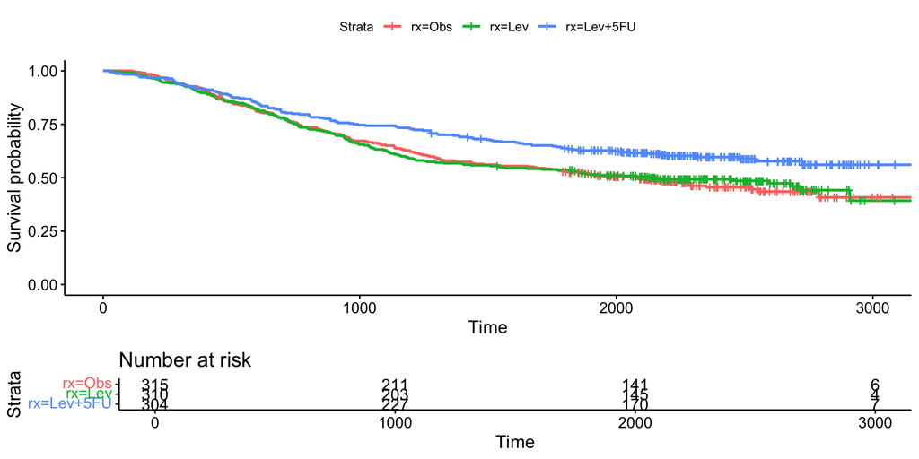

## Multivariate model

```r
model <- coxph(formula = Surv(time, status) ~ rx + surg + obstruct +
    differentiation + node4 + local_spread, data = df)
```

| rx: | Treatment - Obs(ervation), Lev(amisole), Lev(amisole)+5-FU |
| --- | --- |
| surg: | time from surgery to registration (0=short, 1=long) |
| obstruct: | obstruction of colon by tumour |
| node4: | more than 4 positive lymph nodes |
| nodes: | number of lymph nodes with detectable cancer |
| local_spread: | Extent of local spread (1=submucosa, 2=muscle, 3=serosa, 4=contiguous structures) |
| differ: | differentiation of tumour (1=well, 2=moderate, 3=poor) |

## Table 1. Hazard Ratio

[output not shown]

## References

[1]

R. Tibshirani, “What is cox’s proportional hazards model?” *Signif. (Oxf.)*, vol. 19, no. 2, pp. 38–39, Apr. 2022.

[2]

C. A. Bellera, G. MacGrogan, M. Debled, C. T. de Lara, V. Brouste, and S. Mathoulin-Pélissier, “Variables with time-varying effects and the cox model: Some statistical concepts illustrated with a prognostic factor study in breast cancer,” *BMC Med. Res. Methodol.*, vol. 10, no. 1, p. 20, Mar. 2010.